# Comments, with their context

## PDF page 3 9 annotations

FCL-036PDF p. 3HighlightOpen

### Methods / Treatment assignment designs · Table 1

#### Marked text

> ρX

#### Surrounding text / location

Table 1 caption: a representative spatial surface (incidence dependence ρX = 0.5) drawn for illustration.

#### Annotation contents · flin33

> rho?

**View marked passage in the original PDF**

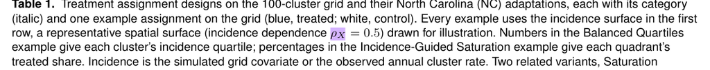

Text selected by annotation coordinates; line-wrap hyphens and mathematical glyph order may reflect PDF extraction. The image below preserves the marked original.

**Chapter 3 follow-up and related comments**

**Provisional chapter destination:** Methods → Treatment Assignment Designs; Application → Geographic Adaptations and Treatment Budgets

Provisional topic mapping, not a verified line-level match or an approved revision.

**Related comments:** FCL-032 · FCL-037

Your notes / intended response

FCL-037PDF p. 3HighlightOpen

### Methods / Treatment assignment designs · Table 1

#### Marked text

> Incidence surface

#### Surrounding text / location

Table 1, first row: Incidence surface. Representative incidence surface used in the design examples below; darker cells represent higher incidence, and dashed lines mark quadrant boundaries.

#### Annotation contents · flin33

> This is not design, right?

**View marked passage in the original PDF**

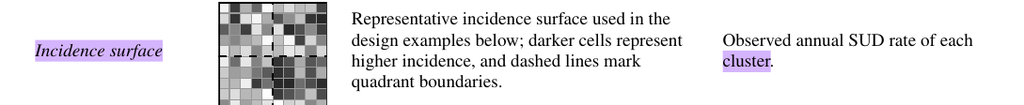

Text selected by annotation coordinates; line-wrap hyphens and mathematical glyph order may reflect PDF extraction. The image below preserves the marked original.

**Chapter 3 follow-up and related comments**

**Provisional chapter destination:** Methods → Treatment Assignment Designs; Application → Geographic Adaptations and Treatment Budgets

Provisional topic mapping, not a verified line-level match or an approved revision.

**Related comments:** FCL-036 · FCL-038

Your notes / intended response

FCL-038PDF p. 3HighlightOpen

### Methods / Treatment assignment designs · Table 1

#### Marked text

> cluster

#### Surrounding text / location

Table 1, Incidence surface row, NC column: Observed annual SUD rate of each cluster.

#### Annotation contents · flin33

> use "region"?

**View marked passage in the original PDF**

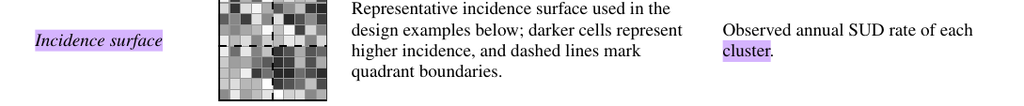

Text selected by annotation coordinates; line-wrap hyphens and mathematical glyph order may reflect PDF extraction. The image below preserves the marked original.

**Chapter 3 follow-up and related comments**

**Provisional chapter destination:** Methods → Treatment Assignment Designs; Application → Geographic Adaptations and Treatment Budgets

Provisional topic mapping, not a verified line-level match or an approved revision.

**Related comments:** FCL-037

Your notes / intended response

FCL-039PDF p. 3HighlightOpen

### Methods / Treatment assignment designs · Table 1

#### Marked text

> gives each the arm less common among its assigned neighbor

#### Surrounding text / location

Table 1, Checkerboard row, NC column: Deterministic map version that visits clusters from most to fewest neighbors and gives each the arm less common among its assigned neighbors (27 treated).

#### Annotation contents · flin33

> I need to understand this.

**View marked passage in the original PDF**

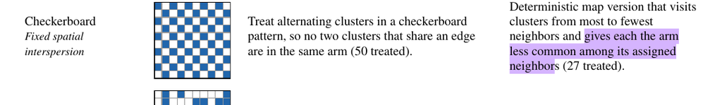

The coordinate extraction clips the last letters of “neighbors”. The full sentence is supplied as context and is visible in the image.

**Chapter 3 follow-up and related comments**

**Provisional chapter destination:** Methods → Treatment Assignment Designs; Application → Geographic Adaptations and Treatment Budgets

Provisional topic mapping, not a verified line-level match or an approved revision.

**Related comments:** FCL-011

Your notes / intended response

FCL-040PDF p. 3HighlightOpen

### Methods / Treatment assignment designs · Table 1

#### Marked text

> k-means clustering on location

#### Surrounding text / location

Table 1, 2 × 2 Blocking row, NC column: Spatial blocking, which treats a random half (rounded) of each of 14 groups formed each year by k-means clustering on location, incidence rank and log-population (27–31 treated by year).

#### Annotation contents · flin33

> Need to understand this

**View marked passage in the original PDF**

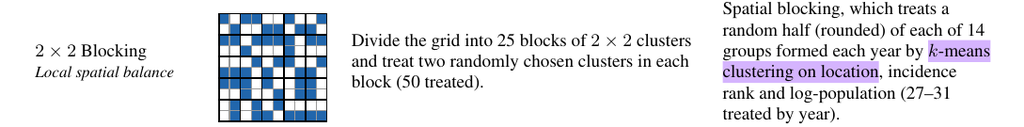

Text selected by annotation coordinates; line-wrap hyphens and mathematical glyph order may reflect PDF extraction. The image below preserves the marked original.

**Chapter 3 follow-up and related comments**

**Provisional chapter destination:** Methods → Treatment Assignment Designs; Application → Geographic Adaptations and Treatment Budgets

Provisional topic mapping, not a verified line-level match or an approved revision.

**Related comments:** FCL-054

Your notes / intended response

FCL-041PDF p. 3StrikeOutOpen

### Methods / Simulation study

#### Marked text

> so

#### Surrounding text / location

Every performance metric is estimated from a finite number of simulated datasets and so carries simulation (Monte Carlo) error.

#### Annotation contents · flin33

> *No written comment; strikeout annotation.*

**View marked passage in the original PDF**

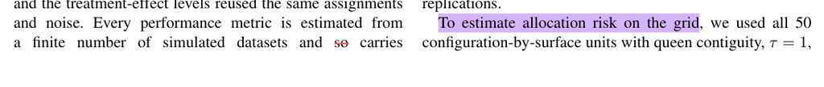

Strikeout only. The PDF contains no written comment for this mark; the marked text is the feedback.

**Chapter 3 follow-up and related comments**

**Provisional chapter destination:** Methods → Heterogeneous Baseline Incidence; Simulation Design, Resampling, and Metrics

Provisional topic mapping, not a verified line-level match or an approved revision.

**Related comments:** None assigned

Your notes / intended response

FCL-042PDF p. 3HighlightOpen

### Methods / Simulation study

#### Marked text

> configurations

#### Surrounding text / location

MCSEs and paired comparisons between designs used the 50 independent configuration-by-surface units (five configurations by ten surfaces), rather than treating settings that share a surface as independent replications.

#### Annotation contents · flin33

> I am confused by "configuration".

**View marked passage in the original PDF**

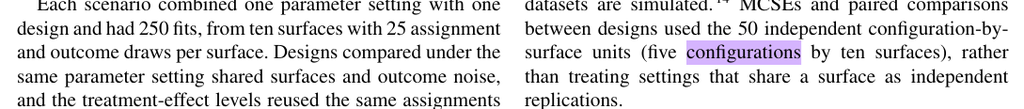

Text selected by annotation coordinates; line-wrap hyphens and mathematical glyph order may reflect PDF extraction. The image below preserves the marked original.

**Chapter 3 follow-up and related comments**

**Provisional chapter destination:** Methods → Heterogeneous Baseline Incidence; Simulation Design, Resampling, and Metrics

Provisional topic mapping, not a verified line-level match or an approved revision.

**Related comments:** FCL-032 · FCL-035

Your notes / intended response

FCL-043PDF p. 3HighlightOpen

### Methods / Simulation study

#### Marked text

> To estimate allocation risk on the grid

#### Surrounding text / location

To estimate allocation risk on the grid, we used all 50 configuration-by-surface units with queen contiguity, τ = 1, ρ ∈ {0, 0.5} and γ ∈ {0.5, 0.8}.

#### Annotation contents · flin33

> Is this part of the results?

**View marked passage in the original PDF**

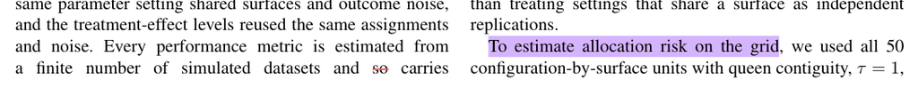

Text selected by annotation coordinates; line-wrap hyphens and mathematical glyph order may reflect PDF extraction. The image below preserves the marked original.

**Chapter 3 follow-up and related comments**

**Provisional chapter destination:** Methods → Heterogeneous Baseline Incidence; Simulation Design, Resampling, and Metrics

Provisional topic mapping, not a verified line-level match or an approved revision.

**Related comments:** FCL-014 · FCL-029

Your notes / intended response

FCL-044PDF p. 3HighlightOpen

### Methods / Treatment assignment designs · Table 1

#### Marked text

> Isolation Buffer

#### Surrounding text / location

Table 1, Isolation Buffer row: treat clusters one at a time, each chosen at random from the untreated clusters with no treated neighbor, until none remain.

#### Annotation contents · flin33

> Is that fair to say this design is not incidence guided but performs very well in the simulation?

**View marked passage in the original PDF**

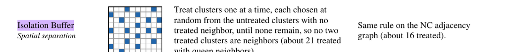

Text selected by annotation coordinates; line-wrap hyphens and mathematical glyph order may reflect PDF extraction. The image below preserves the marked original.

**Chapter 3 follow-up and related comments**

**Provisional chapter destination:** Methods → Treatment Assignment Designs; Application → Geographic Adaptations and Treatment Budgets

Provisional topic mapping, not a verified line-level match or an approved revision.

**Related comments:** None assigned

Your notes / intended response

## PDF page 4 10 annotations

FCL-045PDF p. 4HighlightOpen

### Methods / Application to sudden unexpected death in North Carolina

#### Marked text

> rather than simulated

#### Surrounding text / location

The observed rates were used as fixed inputs rather than simulated (Figure 1), and the four years were analyzed as separate planning scenarios rather than as follow-up of an intervention.

#### Annotation contents · flin33

> What is "simulated"?

**View marked passage in the original PDF**

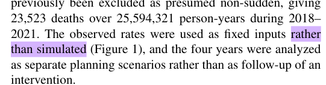

Text selected by annotation coordinates; line-wrap hyphens and mathematical glyph order may reflect PDF extraction. The image below preserves the marked original.

**Chapter 3 follow-up and related comments**

**Provisional chapter destination:** Application to Sudden Unexpected Death in North Carolina → Purpose and Observed Inputs; Geographic Adaptations and Treatment Budgets; Outcome Model, Evaluation and Sensitivity Analyses

Provisional topic mapping, not a verified line-level match or an approved revision.

**Related comments:** None assigned

Your notes / intended response

FCL-046PDF p. 4HighlightOpen

### Methods / Application to sudden unexpected death in North Carolina

#### Marked text

> 1

#### Surrounding text / location

It followed Equation 1 with β = 0, τ = 1 and the row-standardized queen contiguity matrix of the 58 clusters.

#### Annotation contents · flin33

> Use "(1)"?

**View marked passage in the original PDF**

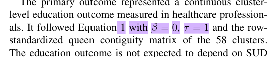

Text selected by annotation coordinates; line-wrap hyphens and mathematical glyph order may reflect PDF extraction. The image below preserves the marked original.

**Chapter 3 follow-up and related comments**

**Provisional chapter destination:** Application to Sudden Unexpected Death in North Carolina → Purpose and Observed Inputs; Geographic Adaptations and Treatment Budgets; Outcome Model, Evaluation and Sensitivity Analyses

Provisional topic mapping, not a verified line-level match or an approved revision.

**Related comments:** FCL-016

Your notes / intended response

FCL-047PDF p. 4HighlightOpen

### Methods / Application to sudden unexpected death in North Carolina

#### Marked text

> with β = 0, τ = 1

#### Surrounding text / location

It followed Equation 1 with β = 0, τ = 1 and the row-standardized queen contiguity matrix of the 58 clusters.

#### Annotation contents · flin33

> Not sure about this

**View marked passage in the original PDF**

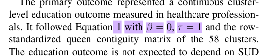

Text selected by annotation coordinates; line-wrap hyphens and mathematical glyph order may reflect PDF extraction. The image below preserves the marked original.

**Chapter 3 follow-up and related comments**

**Provisional chapter destination:** Application to Sudden Unexpected Death in North Carolina → Purpose and Observed Inputs; Geographic Adaptations and Treatment Budgets; Outcome Model, Evaluation and Sensitivity Analyses

Provisional topic mapping, not a verified line-level match or an approved revision.

**Related comments:** FCL-021 · FCL-022 · FCL-053

Your notes / intended response

FCL-048PDF p. 4HighlightOpen

### Methods / Application to sudden unexpected death in North Carolina

#### Marked text

> Application to sudden unexpected death in North Carolina

#### Surrounding text / location

Methods subsection heading: Application to sudden unexpected death in North Carolina.

#### Annotation contents · flin33

> should this section be shown after simulation results?

**View marked passage in the original PDF**

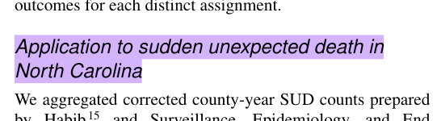

Text selected by annotation coordinates; line-wrap hyphens and mathematical glyph order may reflect PDF extraction. The image below preserves the marked original.

**Chapter 3 follow-up and related comments**

**Provisional chapter destination:** Application to Sudden Unexpected Death in North Carolina → Purpose and Observed Inputs; Geographic Adaptations and Treatment Budgets; Outcome Model, Evaluation and Sensitivity Analyses

Provisional topic mapping, not a verified line-level match or an approved revision.

**Related comments:** FCL-049

Your notes / intended response

FCL-049PDF p. 4HighlightOpen

### Results / Simulation study: the spillover regime determines which designs perform best

#### Marked text

> Incidence configuration changed each design’s MSE by less than 10%, except for High Incidence Focus (Figure 2).

#### Surrounding text / location

Incidence configuration changed each design’s MSE by less than 10%, except for High Incidence Focus (Figure 2).

#### Annotation contents · flin33

> Should this sentence be mentioned later?

**View marked passage in the original PDF**

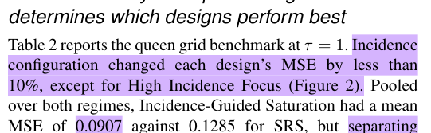

Text selected by annotation coordinates; line-wrap hyphens and mathematical glyph order may reflect PDF extraction. The image below preserves the marked original.

**Chapter 3 follow-up and related comments**

**Provisional chapter destination:** Results → Design Performance Under Queen Contiguity; Spillover Regime; Comparison with Simple Random Sampling

Provisional topic mapping, not a verified line-level match or an approved revision.

**Related comments:** FCL-048

Your notes / intended response

FCL-050PDF p. 4HighlightPartly addressed

### Results / Simulation study: the spillover regime determines which designs perform best

#### Marked text

> 0.0907

#### Surrounding text / location

Pooled over both regimes, Incidence-Guided Saturation had a mean MSE of 0.0907 against 0.1285 for SRS, but separating the regimes was essential.

#### Annotation contents · flin33

> three significant digits? I can't find this number in Table 2.

Author confirmed on 2026-11-11 that the three-decimal reporting rule was adopted after this draft was circulated. The current CTJ source uses 0.091 here. The question about locating the pooled result in the regime-specific Table 2 remains open.

**View marked passage in the original PDF**

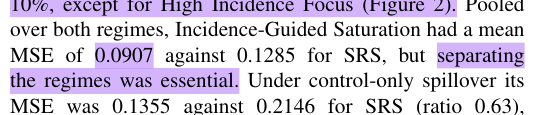

Text selected by annotation coordinates; line-wrap hyphens and mathematical glyph order may reflect PDF extraction. The image below preserves the marked original.

**Chapter 3 follow-up and related comments**

**Provisional chapter destination:** Results → Design Performance Under Queen Contiguity; Spillover Regime; Comparison with Simple Random Sampling

Provisional topic mapping, not a verified line-level match or an approved revision.

**Related comments:** FCL-051 · FCL-055

Your notes / intended response

FCL-051PDF p. 4HighlightOpen

### Results / Simulation study: the spillover regime determines which designs perform best

#### Marked text

> separating the regimes was essential.

#### Surrounding text / location

Pooled over both regimes, Incidence-Guided Saturation had a mean MSE of 0.0907 against 0.1285 for SRS, but separating the regimes was essential.

#### Annotation contents · flin33

> What does this mean?

**View marked passage in the original PDF**

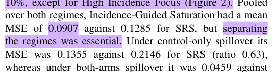

Text selected by annotation coordinates; line-wrap hyphens and mathematical glyph order may reflect PDF extraction. The image below preserves the marked original.

**Chapter 3 follow-up and related comments**

**Provisional chapter destination:** Results → Design Performance Under Queen Contiguity; Spillover Regime; Comparison with Simple Random Sampling

Provisional topic mapping, not a verified line-level match or an approved revision.

**Related comments:** FCL-050 · FCL-058

Your notes / intended response

FCL-052PDF p. 4HighlightOpen

### Results / Simulation study: the spillover regime determines which designs perform best

#### Marked text

> (SI)

#### Surrounding text / location

Their worse control-only accuracy reflects imprecision rather than bias (SI).

#### Annotation contents · flin33

> What does this mean?

**View marked passage in the original PDF**

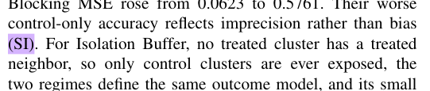

Text selected by annotation coordinates; line-wrap hyphens and mathematical glyph order may reflect PDF extraction. The image below preserves the marked original.

**Chapter 3 follow-up and related comments**

**Provisional chapter destination:** Results → Design Performance Under Queen Contiguity; Spillover Regime; Comparison with Simple Random Sampling

Provisional topic mapping, not a verified line-level match or an approved revision.

**Related comments:** FCL-059

Your notes / intended response

FCL-053PDF p. 4HighlightOpen

### Methods / Application to sudden unexpected death in North Carolina

#### Marked text

> β = 1

#### Surrounding text / location

The education outcome is not expected to depend on SUD incidence, so incidence guided allocation only, and β = 1 served as a hypothetical sensitivity analysis.

#### Annotation contents · flin33

> why beta=1?

**View marked passage in the original PDF**

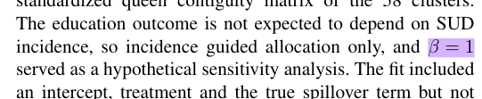

Text selected by annotation coordinates; line-wrap hyphens and mathematical glyph order may reflect PDF extraction. The image below preserves the marked original.

**Chapter 3 follow-up and related comments**

**Provisional chapter destination:** Application to Sudden Unexpected Death in North Carolina → Purpose and Observed Inputs; Geographic Adaptations and Treatment Budgets; Outcome Model, Evaluation and Sensitivity Analyses

Provisional topic mapping, not a verified line-level match or an approved revision.

**Related comments:** FCL-021 · FCL-022 · FCL-047

Your notes / intended response

FCL-054PDF p. 4HighlightOpen

### Methods / Application to sudden unexpected death in North Carolina

#### Marked text

> chosen from 250 k-means candidate partitions for compactness and balance in population, clusters and counties

#### Surrounding text / location

Incidence-Guided Saturation used four fixed geographic regions, chosen from 250 k-means candidate partitions for compactness and balance in population, clusters and counties.

#### Annotation contents · flin33

> Need to understand this

**View marked passage in the original PDF**

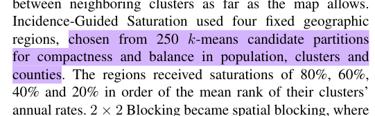

Text selected by annotation coordinates; line-wrap hyphens and mathematical glyph order may reflect PDF extraction. The image below preserves the marked original.

**Chapter 3 follow-up and related comments**

**Provisional chapter destination:** Application to Sudden Unexpected Death in North Carolina → Purpose and Observed Inputs; Geographic Adaptations and Treatment Budgets; Outcome Model, Evaluation and Sensitivity Analyses

Provisional topic mapping, not a verified line-level match or an approved revision.

**Related comments:** FCL-040

Your notes / intended response

## PDF page 5 6 annotations

FCL-055PDF p. 5HighlightOpen

### Results / Simulation study: the spillover regime determines which designs perform best · Table 2

#### Marked text

> outcome-dependence values

#### Surrounding text / location

Table 2 caption: Each regime-specific entry averages 80 scenarios (five incidence configurations, four outcome-dependence values ρ and four spillover-magnitude values γ).

#### Annotation contents · flin33

> change to "spatial dependence coefficient"?

**View marked passage in the original PDF**

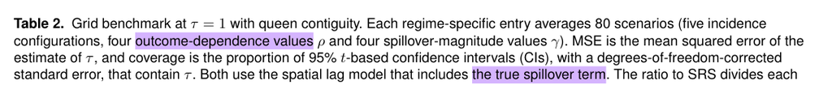

Text selected by annotation coordinates; line-wrap hyphens and mathematical glyph order may reflect PDF extraction. The image below preserves the marked original.

**Chapter 3 follow-up and related comments**

**Provisional chapter destination:** Results → Design Performance Under Queen Contiguity; Comparison with Simple Random Sampling

Provisional topic mapping, not a verified line-level match or an approved revision.

**Related comments:** FCL-050

Your notes / intended response

FCL-056PDF p. 5HighlightOpen

### Results / Simulation study: the spillover regime determines which designs perform best · Table 2

#### Marked text

> the true spillover term

#### Surrounding text / location

Table 2 caption: Both use the spatial lag model that includes the true spillover term.

#### Annotation contents · flin33

> true \gamma?

**View marked passage in the original PDF**

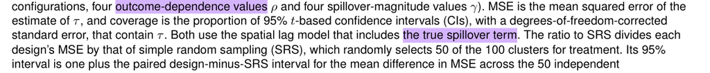

Text selected by annotation coordinates; line-wrap hyphens and mathematical glyph order may reflect PDF extraction. The image below preserves the marked original.

**Chapter 3 follow-up and related comments**

**Provisional chapter destination:** Results → Design Performance Under Queen Contiguity; Comparison with Simple Random Sampling

Provisional topic mapping, not a verified line-level match or an approved revision.

**Related comments:** FCL-030

Your notes / intended response

FCL-057PDF p. 5HighlightOpen

### Results / Simulation study: the spillover regime determines which designs perform best · Table 2

#### Marked text

> N/A

#### Surrounding text / location

Table 2, Simple Random Sampling row: N/A in the Both arms Ratio to SRS (95% CI) column. The Control only reference cell also displays N/A.

#### Annotation contents · flin33

> change to "Reference"?

**View marked passage in the original PDF**

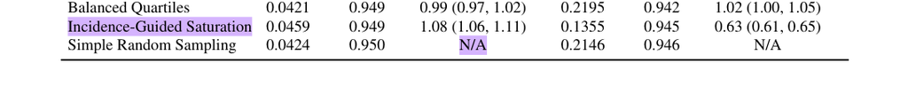

Text selected by annotation coordinates; line-wrap hyphens and mathematical glyph order may reflect PDF extraction. The image below preserves the marked original.

**Chapter 3 follow-up and related comments**

**Provisional chapter destination:** Results → Design Performance Under Queen Contiguity; Comparison with Simple Random Sampling

Provisional topic mapping, not a verified line-level match or an approved revision.

**Related comments:** None assigned

Your notes / intended response

FCL-058PDF p. 5HighlightOpen

### Results / Simulation study: the spillover regime determines which designs perform best · Table 2

#### Marked text

> Both arms

#### Surrounding text / location

Table 2: Both arms column-group heading, over MSE, Coverage and Ratio to SRS (95% CI).

#### Annotation contents · flin33

> Is it fair to say if the spillover happens in both arm, don't bother to design a more complicated sampling? —> Yes, there is no clear alternative design that outperforms SRS

**View marked passage in the original PDF**

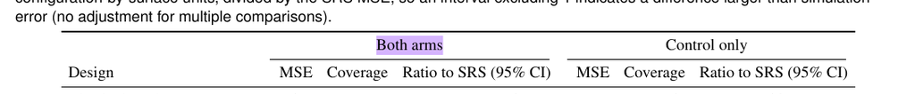

Text selected by annotation coordinates; line-wrap hyphens and mathematical glyph order may reflect PDF extraction. The image below preserves the marked original. The arrow response is part of the current annotation contents. It is preserved verbatim, without assigning authorship to that addition.

**Chapter 3 follow-up and related comments**

**Provisional chapter destination:** Results → Design Performance Under Queen Contiguity; Comparison with Simple Random Sampling

Provisional topic mapping, not a verified line-level match or an approved revision.

**Related comments:** FCL-051 · FCL-059

Your notes / intended response

FCL-059PDF p. 5HighlightOpen

### Results / Simulation study: the spillover regime determines which designs perform best · Table 2

#### Marked text

> Incidence-Guided Saturation

#### Surrounding text / location

Table 2: Incidence-Guided Saturation row, with both-arms MSE 0.0459 and control-only MSE 0.1355 in the annotated draft.

#### Annotation contents · flin33

> This one is a winner. How sensitive can it be for a certain scenario that can damage the estimation?

**View marked passage in the original PDF**

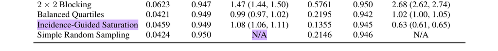

Text selected by annotation coordinates; line-wrap hyphens and mathematical glyph order may reflect PDF extraction. The image below preserves the marked original.

**Chapter 3 follow-up and related comments**

**Provisional chapter destination:** Results → Design Performance Under Queen Contiguity; Comparison with Simple Random Sampling

Provisional topic mapping, not a verified line-level match or an approved revision.

**Related comments:** FCL-044 · FCL-052 · FCL-058 · FCL-060

Your notes / intended response

FCL-060PDF p. 5HighlightOpen

### Results / SUD application: Incidence-Guided Saturation is strong under control-only spillover

#### Marked text

> strong

#### Surrounding text / location

Results subsection heading: SUD application: Incidence-Guided Saturation is strong under control-only spillover.

#### Annotation contents · flin33

> use "the best"? —> preferred?

**View marked passage in the original PDF**

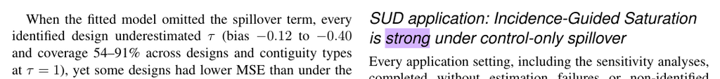

Text selected by annotation coordinates; line-wrap hyphens and mathematical glyph order may reflect PDF extraction. The image below preserves the marked original. The arrow response is part of the current annotation contents. It is preserved verbatim, without assigning authorship to that addition.

**Chapter 3 follow-up and related comments**

**Provisional chapter destination:** Application to Sudden Unexpected Death in North Carolina → Accuracy, Coverage and Reach

Provisional topic mapping, not a verified line-level match or an approved revision.

**Related comments:** FCL-059

Your notes / intended response

## Additional feedback from your notes

Use a separate entry for each additional comment. Include an FCL ID when it belongs with an existing annotation. Otherwise give its page, section and quoted passage, or mark it as a general comment. These notes are separate from the PDF feedback.

Additional notes

Notes typed here stay in browser storage and are not written into this HTML file. Export your notes to keep a portable copy, or send them in chat. An exported notes file can be used to build the revision plan.

## Source and extraction method

2026-11-11-Project-2-Manuscript-Feedback-FCL.pdf · 9 pages · annotations attributed to `flin33`. Prepared 11 November 2026 by Andrew Walther.

Annotation geometry identifies the marked text. Surrounding sentences and exhibit locations were checked against PDF text and the CTJ source. Short formulas in context are transcribed into plain Unicode, with vector boldface omitted. Expand each image to inspect the original typesetting and highlight. The JSON preserves raw extracted text and coordinates.

IDs follow the PDF annotation-array order within each page. A later number may occur higher on a page. Empty popup objects and document links are excluded: 60 popup objects accompany the 60 substantive annotations, and 53 link annotations are navigation rather than feedback. The two strikeouts have no comment text and remain separate entries.

The reviewed PDF differs from the current manuscript, including its numerical precision. Proposed Chapter 3 destinations identify topics only, not verified line-level matches. General questions attached to a table heading or design name remain attached there; their broader implications are for the revision plan.

**Source SHA-256:** `84b5d3e49c0da7760d64386c72774709b6d522daef0e1632624b65f6140ec0c9`